# Texas college crime stats are widely misreported

Sabrina Nystrom

An article started floating around Facebook the other day that discussed the newly released 2015 dataset for self-reported crimes on university and college campuses in the USA. Specifically, this article focused on Texas colleges and was, surprisingly, reporting my alma mater, Austin College to be the 2nd most dangerous college in Texas. This blew my mind. Something had to be wrong. I graduted in 2015. I was there the *entire time*, and I certainly didn’t feel in any danger.

Anyway, something was fishy about their numbers, and their article really rubbed me the wrong way, because damnit they’re wrong, and my alma mater is great. So, I decided to get my hands on the dataset and see if their claims hold true. ([The article in question](http://www.chron.com/news/houston-texas/texas/article/The-safest-and-most-dangerous-college-campuses-in-9967911.php#photo-11438321))

To do this analysis I used the statistical programming language, R. I can produce the full code used to generate graphs upon request, but to keep the article neat and not too scary, I’ve hidden it. I hope I can convince you these numbers are not an accurate picture of the data using simple graphs.

Let’s read in the raw data given by the FBI (found [here](https://ucr.fbi.gov/crime-in-the-u.s/2015/crime-in-the-u.s.-2015/tables/table-9/table-9-state-pieces/table_9_offenses_known_to_law_enforcement_texas_by_university_and_college_2015.xls)) (note: I preprocessed it a bit to make it more easy to read into R, but the numbers were not changed in any way). I required all schools included in the analysis to have reported numbers of enrolled students, for obvious reasons. This only removed 5 schools from the dataset of 67 schools, for a final number of 62 included in this analysis.

```r
crime15 <- read.csv("Data/2015_crime_texas_by_university_and_college.csv",
                    stringsAsFactors = FALSE)


c15 <- crime15
c15$School <- paste0(c15$University.College, c15$Campus)
c15 <- select(c15, -Rape..legacy.definition.3) # Remove column as it contains no data
c15 <- rename(c15, Murder = Murder.and.nonnegligent.manslaughter) %>%
        rename(Rape = Rape..revised.definition.2) %>%
        rename(Larceny = Larceny..theft) %>%
        rename(Vehicle.theft = Motor.vehicle.theft) %>%
        rename(Enrollment = Student.enrollment1)
c15 <- c15[c(14,1:13)]
c15 <- filter(c15, Enrollment > 2) %>% #Remove campuses that don't have enrollment numbers
    select(-University.College, -Campus)
```

Now let’s see what happens when we run the same analysis that The Chron did. As a reminder, they summed all crime instances- violent & nonviolent-reported for a campus and divided by the total number of enrolled students to create a crime normalization factor. The logic behind doing this is to make each school directly comparable, because they though that reporting raw numbers of crimes per campus was unfair for schools with different numbers of students enrolled. This logic does make sense, but it makes a rather large assumption that number of crimes scales linearly with number of students enrolled (I’ll talk about this more later). Finally, they multiplied this normalization factor by 100,000 to generate a “number of crimes per 100,000 students” metric. Why they chose 100,000 doesn’t make much sense to me, as no college in Texas has more than 63,000 enrolled students, but it doesn’t really matter that much because it’s just a scaling factor. If they reported it as “crimes per 1,000 students” or “Crimes per 100 students” it wouldn’t make a difference in the relationships between schools. For the remainder of this post, I’ll use the 100,000 students metric just for consistency with the original article. Just remember that the trends would be the same no matter which number I used.

Here’s the code I used to repeat their analysis, and the results I got:

```r
Summary <- select(c15, School)
Summary$allCrime15 <- c15$Property.crime + c15$Violent.crime
Summary$Enroll15 <- c15$Enrollment
Summary$adjScore <- Summary$allCrime15 / Summary$Enroll15
Summary$ChronCount <- 100000 * Summary$adjScore
result <- arrange(Summary, desc(ChronCount)) %>% select(School, ChronCount)
SummaryTable <- head(result , n = 10)
knitr::kable(SummaryTable, col.names = c("School", "Crimes per 100,000 Students"), digits = 0)
```

| School | Crimes per 100,000 Students |
| --- | --- |
| University of Texas:Houston | 6833 |
| University of Texas:Southwestern Medical School | 5724 |
| University of Texas:Medical Branch | 3550 |
| Rice University | 3172 |
| Austin College | 2613 |
| Texas Southern University | 2513 |
| Southwestern University | 2211 |
| University of Texas:Health Science Center, San Antonio | 2034 |
| Sul Ross State University | 1984 |
| Texas State Technical College: Waco | 1920 |

Yep, the values are the same. I’ve sorted the results in descending order based on the number of crimes per 100,000 Students, and I also recapitulate their rankings. Note that I did not exclude schools with alternative campuses, which is why some schools (like UT-Southwestern, which wasn’t included in the original analysis) don’t match up with the exact ranks from the original article.

## What’s wrong with their numbers?

If we plot the normalized values of all crimes per student vs. the normalized value of each specific crime type it becomes apparent that the only crime with a linear relationship to total normalized crime values is Larceny. This means that the primary crime contributing to the “crime per students” value is petty theft; this isn’t that surprising, but it does illustrate that the reported value is really only a reflection of whether students are likely to be stolen from, not robbed at gunpoint, assaulted, or murdered.

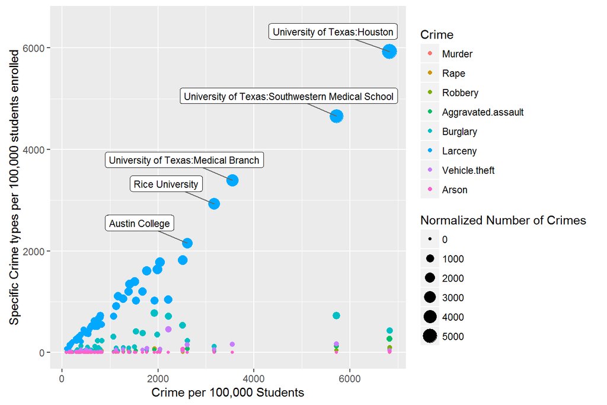

To illustrate this point further, I stratified the data into violent vs property crime and repeated the previous analysis. As you can observe, violent crime does not scale with increases in normalized crime values. In short, this means that Property crime was the primary contributor to on-campus crime in 2015, and that of the specific types of property crime, Larceny is the primary driver of this association.

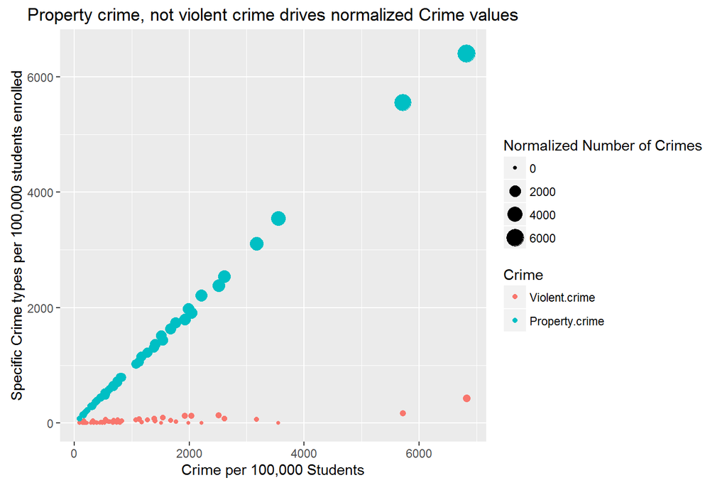

## Do normalized crime values accurately represent campus crime rates?

Getting to the bulk of my problem with these articles, it appears that schools with low enrollment are scoring disproportionatly highly in the “Crime per 100,000 students” metric. The effect is very obvious in the plot below: each point represents a school, and you can easily see that schools with the highest normalized crime values are those with low enrollment. I think this is because there is some absolute minimum number of crimes that will occurr per campus which when divided by small numbers of students makes the crime rate appear higher.

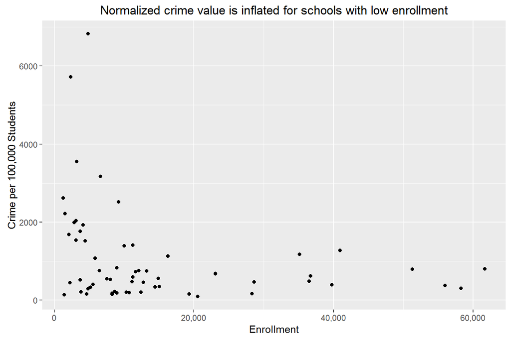

To test this I’ve plotted the total number of crimes per campus (unnormalized) vs. the normalized crimes per students value. Each point represents a College or University. The size of each point represents the enrollment size of the college. When plotted this way, you can see that schools with high absolute numbers of crimes score as having low normalized crime values, and schools with lower enrollments actually tend to have lower total numbers of crimes while still scoring as having higher numbers of “crimes per student”. This suggests that higher numbers of students, not lower numbers of crime are driving the crimes per student metric down. Finally, most colleges tend to have below 250 crimes per campus, regardless of enrollment size. This suggests that the number of crimes at a college campus does not scale linearly with the enrollment of the school, which means it **Should not** be used as a normalization factor!

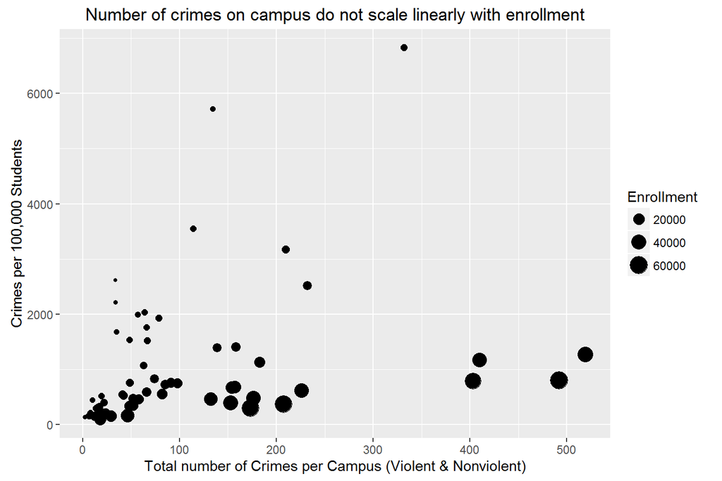

Just to hammer this point home, this graph from simulated data shows what the above plot *would* look like if enrollment scaled linearly with the normalized crime data. Note how the dot size increases as crimes per campus *and* crimes per 100,000 students increase.

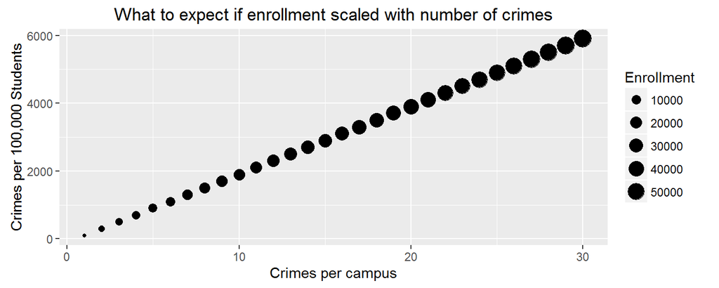

To zoom in on this effect in more detail, I’ve plotted the Enrollment vs. Total number of crimes per campus. As I demonstrated in the previous graphs, again the total number of crimes tends to be below 250 crimes per campus, with campuses enrolling large numbers of students trending towards having higher numbers of crimes. Interestingly, campuses with higher raw numbers of crimes don’t have high normalized crime scores (as reflected by the size of the points), but campuses with low total numbers of crimes do. This further suggests that the normalized crime metric is being skewed by low enrollments.

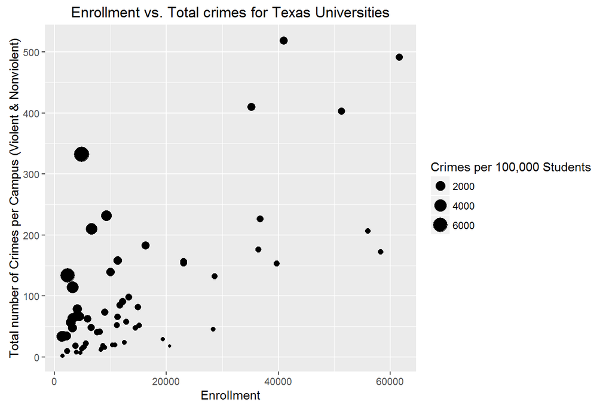

## Total crimes for Schools enrolling less than 20000 Students is not correlated with increasing enrollment

It appears that colleges in this dataset that enroll less than 20000 students behave differently than colleges enrolling high numbers of students (they tend to exhibit around 100 crimes per campus each). Because these articles are reporting high levels of crime for smaller colleges and universities, let’s zoom in on those campuses to see if there’s a trend.

When plotting the data for only schools enrolling under 20000 students, it appears that the number of crimes per campus does not fluctuate greatly with student number, therefore normalizing data based on number of students will incorrectly inflate the relative number of crimes per student for schools enrolling fewer students. As for the top 5 scoring schools, I’ll let the graph speak for itself as to whether the “crimes per student” normalization does them justice (Hint: it doesn’t).

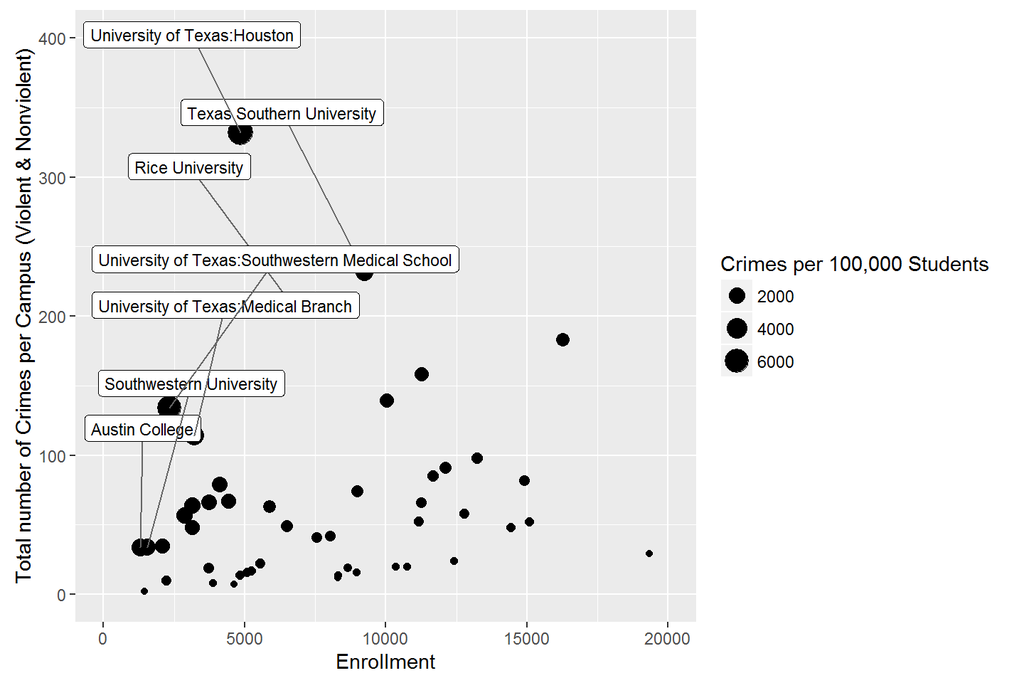

## What did we learn?

- Nonviolent crime is the primary source of reported crime on college campuses
- College campuses probably have some baseline number of crimes that will be reported on them annually that is not related to the size of the school
- Don’t assume associations between variables are linear.
- Austin College is probably not the 2nd most crime-ridden campus in Texas.
- Checking a Journalist’s math is a great way to spend an afternoon.